# Color-Spaces

```
Color Spaces
@arashsm79
```

- Converting RGB to HSI manually
- Color slicing in HSI
- Color slicing in RGB
- Gamma correction
- Saturation adjustment
- Hue shifting

```python
import numpy as np
import math
import cv2
import matplotlib.pyplot as plt
import random as rnd
from PIL import Image, ImageOps
```

This function nomalizes the image into the range [0, 1]

```python
def normalize(img):
    return (img - img.min()) / (img.max()- img.min())
```

## Converting RGB to HSI manually

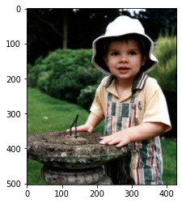

```python
e1img_rgb = Image.open("park.png")
e1img_rgb = np.array(e1img_rgb)
plt.imshow(e1img_rgb)
```

Cast the image from uint8 to float.

```python
e1img_rgb_int = e1img_rgb.copy()
e1img_rgb = np.float64(e1img_rgb) / 255
```

Seperate the RGB channels.

```python
e1img_red = e1img_rgb[:, :, 0]
e1img_green = e1img_rgb[:, :, 1]
e1img_blue = e1img_rgb[:, :, 2]
```

This functions calculates the intensity of an RGB image.

```python
def get_intensity(red, green, blue):
    return (red + green + blue) / 3
```

This functions calculates the saturation of an RGB image.

```python
def get_saturation(red, green, blue):
    channel_sum =  red + green + blue
    return 1 - np.divide(3, channel_sum, out = np.zeros_like(channel_sum), where=channel_sum!=0)\
                    * np.minimum(np.minimum(red, green), blue)
```

This functions calculates the hue of an RGB image.

```python
def get_hue(red, green, blue):
    hue = np.copy(red)
    for i in range(red.shape[0]):
        for j in range(red.shape[1]):
            numerator =  0.5 * ((red[i][j] - green[i][j]) + (red[i][j] - blue[i][j]))
            denominator = math.sqrt((red[i][j] - green[i][j])**2 + ((red[i][j] - blue[i][j]) * (green[i][j] - blue[i][j])))
            hue[i][j] = np.divide(numerator, denominator, out = np.zeros_like(numerator), where=denominator!=0)
            hue[i][j] = math.degrees(math.acos(hue[i][j]))
            if blue[i][j] <= green[i][j]:
                hue[i][j] = hue[i][j]
            else:
                hue[i][j] = 360 - hue[i][j]
    return hue
```

convert RGB to HSI

```python
# Intensity
e1img_intensity = get_intensity(e1img_red ,e1img_green ,e1img_blue)
```

```python
# Saturation
e1img_saturation = get_saturation(e1img_red ,e1img_green ,e1img_blue)
```

```python
# Hue
e1img_hue = get_hue(e1img_red ,e1img_green ,e1img_blue)
```

Normalize the channels

```python
e1img_hue = normalize(e1img_hue)
e1img_saturation = normalize(e1img_saturation)
e1img_intensity = normalize(e1img_intensity)
```

```python
e1img_hsi = np.stack([np.uint16(e1img_hue * 359), np.uint8(e1img_saturation * 255), np.uint8(e1img_intensity * 255)], axis=2)
```

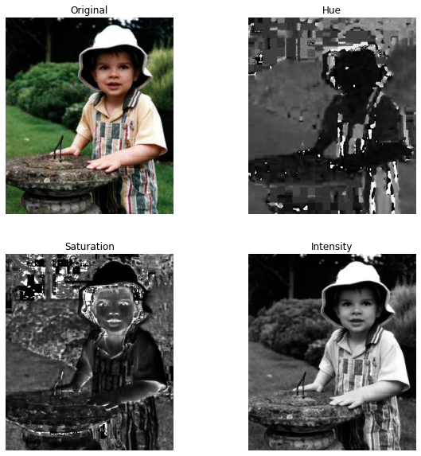

```python
plt.figure(figsize=(10, 10))
plt.subplot(2, 2, 1)
plt.axis("off")
plt.title("Original")
plt.imshow(e1img_rgb)
plt.subplot(2, 2, 2)
plt.axis("off")
plt.title("Hue")
plt.imshow(e1img_hue, cmap="gray")
plt.subplot(2, 2, 3)
plt.axis("off")
plt.title("Saturation")
plt.imshow(e1img_saturation, cmap="gray")
plt.subplot(2, 2, 4)
plt.axis("off")
plt.title("Intensity")
plt.imshow(e1img_intensity, cmap="gray")
```

- The intensity component of HSI shows the overall image
- Hue is the same for parts of the image that have similar colors
- We can still make out what the image is about using saturation. But with hue, it's hard to tell what the image is about.

Calculate the histogram of each channel. All channels are in the range [0, 255] except for hue which is in the range [0, 359]

```python
hist_r = [0] * 256
hist_g = [0] * 256
hist_b = [0] * 256

hist_h = [0] * 360
hist_s = [0] * 256
hist_i = [0] * 256

for i in range(e1img_rgb_int.shape[0]):
    for j in range(e1img_rgb_int.shape[1]):
        hist_r[e1img_rgb_int[i][j][0]] = hist_r[e1img_rgb_int[i][j][0]] + 1
        hist_b[e1img_rgb_int[i][j][1]] = hist_b[e1img_rgb_int[i][j][1]] + 1
        hist_g[e1img_rgb_int[i][j][2]] = hist_g[e1img_rgb_int[i][j][2]] + 1

for i in range(e1img_hsi.shape[0]):
    for j in range(e1img_hsi.shape[1]):
        hist_h[e1img_hsi[i][j][0]] = hist_h[e1img_hsi[i][j][0]] + 1
        hist_s[e1img_hsi[i][j][1]] = hist_s[e1img_hsi[i][j][1]] + 1
        hist_i[e1img_hsi[i][j][2]] = hist_i[e1img_hsi[i][j][2]] + 1
```

```python
hist_dom_256 = np.arange(0, 256, 1, dtype=np.uint8)
hist_dom_360 = np.arange(0, 360, 1, dtype=np.uint8)
```

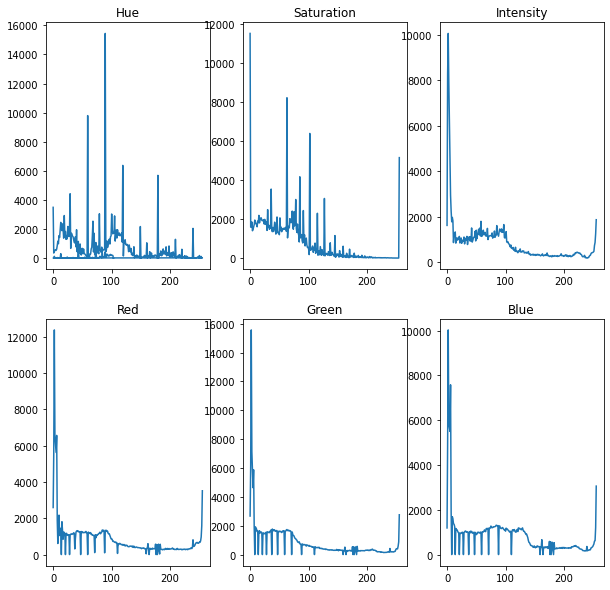

```python
plt.figure(figsize=(10, 10))
plt.subplot(2, 3, 1)
plt.title("Hue")
plt.plot(hist_dom_360, hist_h)
plt.subplot(2, 3, 2)
plt.title("Saturation")
plt.plot(hist_dom_256, hist_s)
plt.subplot(2, 3, 3)
plt.title("Intensity")
plt.plot(hist_dom_256, hist_i)
plt.subplot(2, 3, 4)
plt.title("Red")
plt.plot(hist_dom_256, hist_r)
plt.subplot(2, 3, 5)
plt.title("Green")
plt.plot(hist_dom_256, hist_g)
plt.subplot(2, 3, 6)
plt.title("Blue")
plt.plot(hist_dom_256, hist_b)
```

- The histogram of Intensity in HSI is a lot like the histograms of RGB channels.
- The histogram of saturation in HSI is closer to the histograms of RGB channels than hue is.
- The histogram of hue in HSI is quite different from the rest of the histograms.

## Color slicing in HSI

[figure not shown]

```python
e2img_rgb = Image.open("painting.jpg")
e2img_rgb = np.array(e2img_rgb)
e2img_rgb_int = e2img_rgb.copy()
plt.imshow(e2img_rgb)
```

Cast the image from uint8 to float.

```python
e2img_rgb = np.float64(e2img_rgb) / 255
```

Seperate the RGB channels.

```python
e2img_red = e2img_rgb[:, :, 0]
e2img_green = e2img_rgb[:, :, 1]
e2img_blue = e2img_rgb[:, :, 2]
```

convert RGB to HSI

```python
# Intensity
e2img_intensity = get_intensity(e2img_red ,e2img_green ,e2img_blue)
```

```python
# Saturation
e2img_saturation = get_saturation(e2img_red ,e2img_green ,e2img_blue)
```

```python
# Hue
e2img_hue = get_hue(e2img_red ,e2img_green ,e2img_blue)
```

Normalize the channels

```python
e2img_hue = normalize(e2img_hue)
e2img_saturation = normalize(e2img_saturation)
e2img_intensity = normalize(e2img_intensity)
```

```python
e2img_hsi = np.stack([np.uint16(e2img_hue * 359), np.uint8(e2img_saturation * 255), np.uint8(e2img_intensity * 255)], axis=2)
```

[figure not shown]

```python
plt.figure(figsize=(10, 10))
plt.subplot(2, 2, 1)
plt.axis("off")
plt.title("Original")
plt.imshow(e2img_rgb)
plt.subplot(2, 2, 2)
plt.axis("off")
plt.title("Hue")
plt.imshow(e2img_hue, cmap="gray")
plt.subplot(2, 2, 3)
plt.axis("off")
plt.title("Saturation")
plt.imshow(e2img_saturation, cmap="gray")
plt.subplot(2, 2, 4)
plt.axis("off")
plt.title("Intensity")
plt.imshow(e2img_intensity, cmap="gray")
```

Binary mask generated by thresholding the saturation image with a threshold equal to `threshold` percent of the maximum value in that image. Any pixel value greater than the threshold was set to 1 (white). All others were set to 0 (black).

```python
color_seg_sat_mask = np.zeros_like(e2img_hue)
color_seg_sat_threshold = 0.5 * np.max(e2img_hsi[:, :, 1])
for i in range(e2img_hsi.shape[0]):
    for j in range(e2img_hsi.shape[1]):
        if e2img_hsi[i][j][1] > color_seg_sat_threshold:
            color_seg_sat_mask[i][j] = 1
        else:
            color_seg_sat_mask[i][j] = 0
```

[figure not shown]

```python
color_seg_sat_mask_image = np.multiply(e2img_hue, color_seg_sat_mask)
plt.imshow(color_seg_hsi_image, cmap='gray')
```

We see in the hue image that high values (which are the values of interest) are grouped at the very high end, near 1.0. Thus, we create a threshold mask based on hue.

```python
color_seg_hsi_mask = np.zeros_like(e2img_rgb)
color_seg_hsi_threshold = 0.95
for i in range(e2img_hsi.shape[0]):
    for j in range(e2img_hsi.shape[1]):
        if color_seg_sat_mask_image[i][j] > color_seg_hsi_threshold:
            color_seg_hsi_mask[i][j] = 1
        else:
            color_seg_hsi_mask[i][j] = 0
```

Element wise product of the RGB image and the color slicing mask.

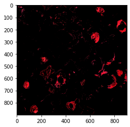

```python
hsi_color_sliced_image = np.multiply(e2img_rgb, color_seg_hsi_mask)
plt.imshow(hsi_color_sliced_image)
```

## Color slicing in RGB

Given a set of sample color points representative of the colors of interest, we obtain an estimate of the “average” color that we wish to segment. Let this average color be denoted by the RGB vector a. So First, I need to calculate $a$.

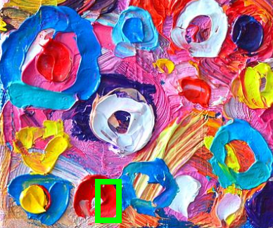

Create the box

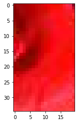

```python
box_cords = (840, 875, 150, 170)
box = e2img_rgb[box_cords[0]:box_cords[1], box_cords[2]:box_cords[3]]

plt.imshow(box)
```

Take the mean of the box

```python
a = box.reshape(box.shape[0]*box.shape[1], box.shape[2]).mean(axis=0)
a
```

```
array([0.88009524, 0.08368627, 0.10322689])
```

Create a mask. All the pixels that have a distance above `color_slicing_threshold` are set to 0, the rest are set to 1.

```python
color_slicing_threshold = 0.1
color_slicing_mask = np.zeros_like(e2img_rgb)
for i in range(e2img_rgb.shape[0]):
    for j in range(e2img_rgb.shape[1]):
        z = e2img_rgb[i][j]
        d = np.linalg.norm(a - z)
        if d < color_slicing_threshold:
            color_slicing_mask[i][j] = 1
        else:
            color_slicing_mask[i][j] = 0
```

Element wise product of the RGB image and the color slicing mask.

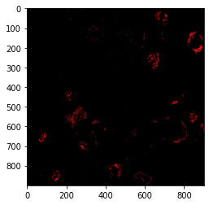

```python
rgb_color_sliced_image = np.multiply(e2img_rgb, color_slicing_mask)
plt.imshow(rgb_color_sliced_image)
```

Calculate the histogram of each channel. All channels are in the range [0, 225]]

```python
def calculate_historgram(img):
    hist_r = [0] * 256
    hist_g = [0] * 256
    hist_b = [0] * 256
    for i in range(e1img_rgb_int.shape[0]):
        for j in range(e1img_rgb_int.shape[1]):
            hist_r[img[i][j][0]] = hist_r[img[i][j][0]] + 1
            hist_b[img[i][j][1]] = hist_b[img[i][j][1]] + 1
            hist_g[img[i][j][2]] = hist_g[img[i][j][2]] + 1
    hist_r[0] = 0
    hist_g[0] = 0
    hist_b[0] = 0
    return (hist_r, hist_g, hist_b)
```

```python
(rgb_sliced_r, rgb_sliced_g, rgb_sliced_b) = calculate_historgram(np.uint8(rgb_color_sliced_image * 255))
(hsi_sliced_r, hsi_sliced_g, hsi_sliced_b) = calculate_historgram(np.uint8(hsi_color_sliced_image * 255))
```

```python
(rgb_orig_r, rgb_orig_g, rgb_orig_b) = calculate_historgram(e2img_rgb_int)
```

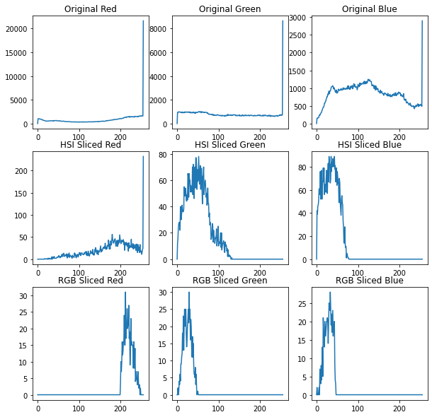

```python
plt.figure(figsize=(10, 10))

plt.subplot(3, 3, 1)
plt.title("Original Red")
plt.plot(hist_dom_256, rgb_orig_r)
plt.subplot(3, 3, 2)
plt.title("Original Green")
plt.plot(hist_dom_256, rgb_orig_g)
plt.subplot(3, 3, 3)
plt.title("Original Blue")
plt.plot(hist_dom_256, rgb_orig_b)


plt.subplot(3, 3, 4)
plt.title("HSI Sliced Red")
plt.plot(hist_dom_256, hsi_sliced_r)
plt.subplot(3, 3, 5)
plt.title("HSI Sliced Green")
plt.plot(hist_dom_256, hsi_sliced_g)
plt.subplot(3, 3, 6)
plt.title("HSI Sliced Blue")
plt.plot(hist_dom_256, hsi_sliced_b)

plt.subplot(3, 3, 7)
plt.title("RGB Sliced Red")
plt.plot(hist_dom_256, rgb_sliced_r)
plt.subplot(3, 3, 8)
plt.title("RGB Sliced Green")
plt.plot(hist_dom_256, rgb_sliced_g)
plt.subplot(3, 3, 9)
plt.title("RGB Sliced Blue")
plt.plot(hist_dom_256, rgb_sliced_b)
```

As you can see, after slicing the images and extracting the red colors, we can see that in the histogram the pixels with high value red color have more frequency. Extracting red colors with *RGB Sliced* yields way better results than *HSI Sliced*. Although working in HSI space is more intuitive in the sense of colors being represented in a more familiar format, segmentation is one area in which better results generally are obtained by using RGB color vectors.

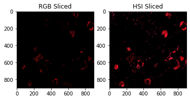

```python
plt.subplot(1, 2, 1)
plt.title("RGB Sliced")
plt.imshow(rgb_color_sliced_image)
plt.subplot(1, 2, 2)
plt.title("HSI Sliced")
plt.imshow(hsi_color_sliced_image)
```

## Saturation adjustment

[figure not shown]

```python
e3img_rgb = Image.open("Lena.bmp")
e3img_rgb = np.array(e3img_rgb)
plt.imshow(e3img_rgb)
```

```python
e3img_hsi = cv2.cvtColor(e3img_rgb, cv2.COLOR_RGB2HSV)
```

```python
sat_increase = 50
e3img_hsi_sat_corr = e3img_hsi.copy()
for i in range(e3img_hsi_sat_corr.shape[0]):
    for j in range(e3img_hsi_sat_corr.shape[1]):
        e3img_hsi_sat_corr[i][j][1] = (e3img_hsi_sat_corr[i][j][1] + sat_increase) % 256
```

[figure not shown]

```python
e3img_hsi_sat_corr_rgb = cv2.cvtColor(e3img_hsi_sat_corr, cv2.COLOR_HSV2RGB)
plt.imshow(e3img_hsi_sat_corr_rgb)
```

## Gamma Correction

```python
def gamma_lut(gamma):
	return np.array([((i / 255.0) ** (1.0 / gamma)) * 255 for i in np.arange(0, 256)]).astype("uint8")
```

```python
lut = gamma_lut(3)
component = 2
e3img_rgb_gamma_corr = e3img_rgb.copy()
for i in range(e3img_rgb_gamma_corr.shape[0]):
    for j in range(e3img_rgb_gamma_corr.shape[1]):
        e3img_rgb_gamma_corr[i][j][component] = lut[e3img_rgb_gamma_corr[i][j][component]]
```

[figure not shown]

```python
plt.imshow(e3img_rgb_gamma_corr)
```

## Hue Shifting

```python
e3img_hsi_32 = np.uint32(e3img_hsi)
```

```python
e3img_hsi_32[:,:,0] = e3img_hsi_32[:,:,0] * 2
```

```python
shift_delta = 50
e3img_hsi_hue_shift = e3img_hsi_32.copy()
for i in range(e3img_hsi_hue_shift.shape[0]):
    for j in range(e3img_hsi_hue_shift.shape[1]):
        e3img_hsi_hue_shift[i][j][0] = (e3img_hsi_hue_shift[i][j][0] + shift_delta) % 359
```

[figure not shown]

```python
e3img_hsi_hue_shift[:,:,0] = e3img_hsi_hue_shift[:,:,0] / 2
e3img_hsi_hue_shifted_half = np.uint8(e3img_hsi_hue_shift)
e3img_hsi_hue_shift_rgb = cv2.cvtColor(e3img_hsi_hue_shifted_half, cv2.COLOR_HSV2RGB)
plt.imshow(e3img_hsi_hue_shift_rgb)
```